# 231B - Section 7

Natalia Garbiras-Diaz

March 10, 2017

```r
rm(list=ls())
```

# Today:

**Using (not abusing) covariates in analysis**

- Rescaling the dependent variable so that potential outcomes have less variance.
- Covariates as moderators (heterogeneous treatment effects)
- Problem set, problem 5

# A DGP (building losely from Miguel et. al)

```r
# Pre-treatment covariates
conflict_pre <- rnorm(100, 95, 4)
rural <- rbinom(100, 1, .7)
ethnic_frac <- rnorm(100, .45, .3)


# Potential outcomes
y_i0 <- 2.5*conflict_pre
y_i1 <- y_i0 - rnorm(100, 10, 5) + rnorm(100, 4*ethnic_frac, 3) - 8*rural
```

[figure not shown]

```r
true_ace <- mean(y_i1) - mean (y_i0)
true_ace
```

```
## [1] -14.94492
```

# Difference in differences: a simulation

```r
experiment <- function(){

    rainfall <- rbinom(100, 1, .5)
    observed_conflict <- ifelse(rainfall==1, y_i1, y_i0)

    # simple difference of means
    DM <- t.test(observed_conflict ~ rainfall)$estimate[2] -
                    t.test(observed_conflict ~ rainfall)$estimate[1]

    # rescaling outcome (difference in differences)
    rescaled <- observed_conflict - conflict_pre
    DiD <- t.test(rescaled ~ rainfall)$estimate[2] -
                    t.test(rescaled ~ rainfall)$estimate[1]

    # return
    return(c(DM, DiD))

}
```

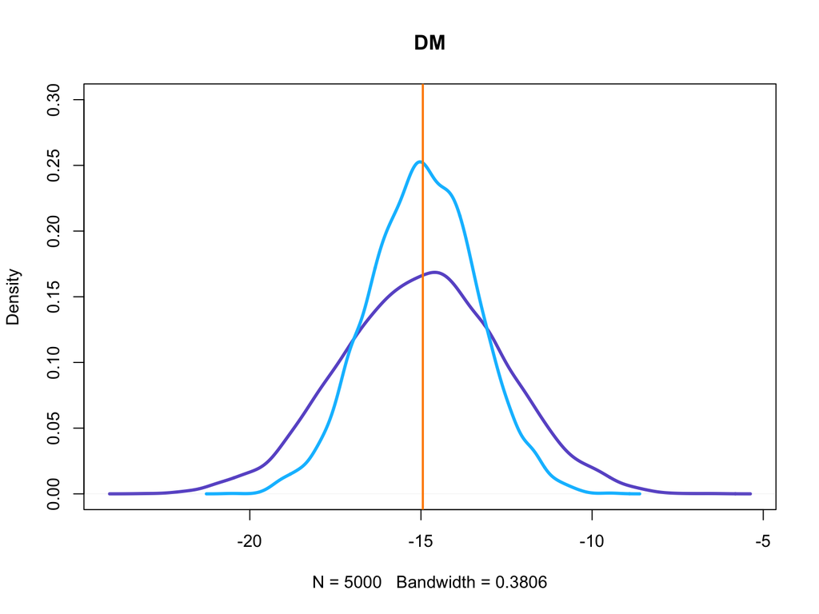

```r
reps <- replicate(5000, experiment())
rownames(reps) <- c("DM", "DiD")

plot(density(reps[1,]), col="slateblue", main="DM", lwd=3, ylim=c(0, .3))
lines(density(reps[2,]), col="deepskyblue", lwd=3)
abline(v=true_ace, lwd=2, col="darkorange")
```

```r
apply(reps, MARGIN=1, FUN=mean)
```

```
##        DM       DiD
## -14.95936 -14.95322
```

```r
apply(reps, MARGIN=1, FUN=sd)
```

```
##       DM      DiD
## 2.322876 1.551524
```

What can we say about the difference between these estimators? Is one of them “better”? If so, how so?

Our simulation shows the unbiasedness of the DiD estimator.

In terms of precision, we saw in lecture that the DiD estimator may be more precise, but that this is true only when the pre-treatment value of the outcome strongly predicts potential outcomes. Formally,

$$Cov(Y_i(0), X_i) + Cov(Y_i(1), X_i) > Var(X_i)$$

What are the values for these elements in our example?

```r
var(conflict_pre)
```

```
## [1] 16.90628
```

```r
cov(y_i1, conflict_pre)
```

```
## [1] 47.55164
```

```r
cov(y_i0, conflict_pre)
```

```
## [1] 42.26569
```

```r
cov(y_i1, conflict_pre) + cov(y_i0, conflict_pre) > var(conflict_pre)
```

```
## [1] TRUE
```

How can we modify the simulation to show this?

```r
potential_outcomes <- function(sd_x){

    conflict_pre <- rnorm(100, 95, sd_x)

    y_i0 <- 2.5*conflict_pre
    y_i1 <- 1.1*y_i0 - 10 + 4*ethnic_frac - 2*rural

    return(cbind(y_i1, y_i0))

    }

experiment <- function(PO){

    rainfall <- rbinom(100, 1, .5)
    observed_conflict <- ifelse(rainfall==1, PO$y_i1, PO$y_i0)

    # rescaling outcome (difference in differences)
    rescaled <- observed_conflict - conflict_pre
    DiD <- t.test(rescaled ~ rainfall)$estimate[2] -
                    t.test(rescaled ~ rainfall)$estimate[1]

    # return
    return(DiD)

}

sim <- function(sd_x){

    PO <- as.data.frame(potential_outcomes(sd_x=sd_x))

    reps <- replicate(5000, experiment(PO=PO))

    lines(density(reps), col="deepskyblue", lwd=3)

}
```

What do we expect as $sd(X)$ increases?

```r
sd_x <- seq(.1, 10, by=2.5)
sd_x
```

```
## [1] 0.1 2.6 5.1 7.6
```

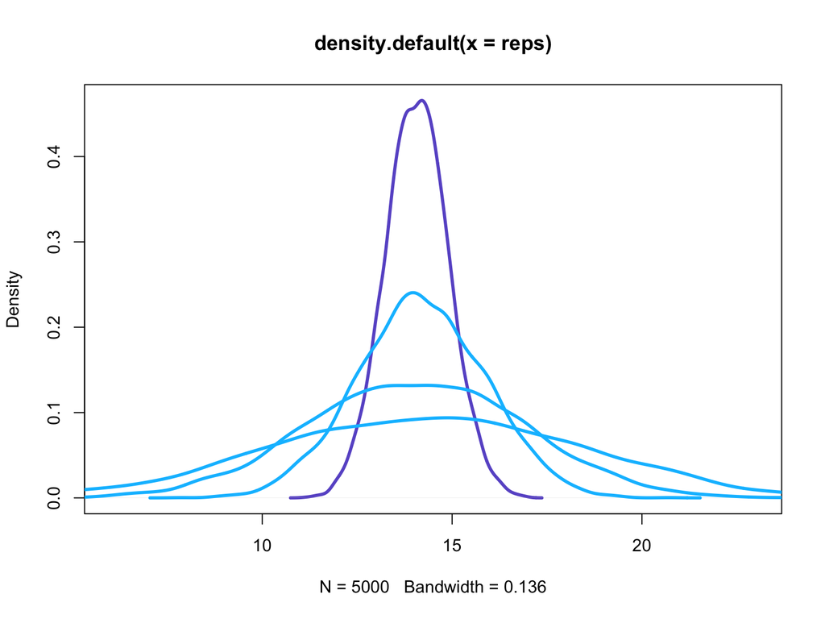

```r
PO <- as.data.frame(potential_outcomes(sd_x=sd_x[1]))
reps <- replicate(5000, experiment(PO=PO))
plot(density(reps), col="slateblue", lwd=3, xlim=c(6,23))

for (i in 2:length(sd_x)){
    sim(sd_x=sd_x[i])
}
```

# Moderators in experiments

Let’s go back to our original example and take one of the possible experiments.

```r
rainfall <- rbinom(100, 1, .5)
observed_conflict <- ifelse(rainfall==1, y_i1, y_i0)

t.test(observed_conflict ~ rainfall)
```

```
##
##  Welch Two Sample t-test
##
## data:  observed_conflict by rainfall
## t = 6.1034, df = 92.928, p-value = 2.374e-08
## alternative hypothesis: true difference in means is not equal to 0
## 95 percent confidence interval:
##   9.754051 19.162416
## sample estimates:
## mean in group 0 mean in group 1
##        236.8602        222.4020
```

Our ``theory’’ predicts that we the effect of rainfall should be larger in rural than urban communities. How can we incorporate this to our empirical analysis?

To make the analysis easier, let’s put the data in a dataframe

```r
data <- as.data.frame(cbind(rural, conflict_pre, observed_conflict, rainfall))


test.rural <- with(data[rural==1,], t.test(observed_conflict ~ rainfall))
test.rural
```

```
##
##  Welch Two Sample t-test
##
## data:  observed_conflict by rainfall
## t = 6.8559, df = 68.018, p-value = 2.573e-09
## alternative hypothesis: true difference in means is not equal to 0
## 95 percent confidence interval:
##  12.38533 22.55493
## sample estimates:
## mean in group 0 mean in group 1
##        236.8021        219.3320
```

```r
test.urban <- with(data[rural==0,], t.test(observed_conflict ~ rainfall))
test.urban
```

```
##
##  Welch Two Sample t-test
##
## data:  observed_conflict by rainfall
## t = 1.1993, df = 23.917, p-value = 0.2422
## alternative hypothesis: true difference in means is not equal to 0
## 95 percent confidence interval:
##  -4.245446 16.017270
## sample estimates:
## mean in group 0 mean in group 1
##        237.0256        231.1397
```

Can we conclude something from this analysis?

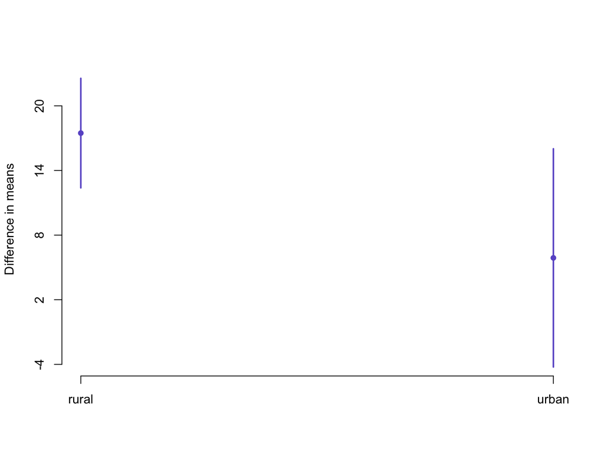

```r
d.r <- test.rural$estimate[1] - test.rural$estimate[2]
d.u <- test.urban$estimate[1] - test.urban$estimate[2]

min <- round(min(test.urban$conf.int), 0)
max <- round(max(test.rural$conf.int), 0)

plot(1:2, c(d.r, d.u), ylim=c(min,max), pch=16, col="slateblue",
     ylab="Difference in means", axes=F, xlab="")
segments(1:2, c(test.rural$conf.int[1], test.urban$conf.int[1]),
         1:2, c(test.rural$conf.int[2], test.urban$conf.int[2]),
         lwd=2, col="slateblue")
axis(2, seq(min, max, round(abs(max/min), 0)))
axis(1, 1:2, labels=c("rural", "urban"))
```

What can we say about this? Does the rural vs. urban divide matter? Why? Why not?

We want a formal test for the difference between these differences.

What elements do we need to calculate that?

```r
diff_in_diff <- d.r - d.u
```

How do we find the SE of this difference?

```r
rural <- data[data$rural==1,]
urban <- data[data$rural==0,]

var1.r <- var(rural$observed_conflict[rural$rainfall==1])
var0.r <- var(rural$observed_conflict[rural$rainfall==0])
varN1.r <- var1.r/length(rural$observed_conflict[rural$rainfall==1])
varN0.r <- var0.r/length(rural$observed_conflict[rural$rainfall==0])
se.diff.r <- sqrt(varN1.r + varN0.r)

d.r/se.diff.r
```

```
## mean in group 0
##        6.855907
```

```r
test.rural
```

```
##
##  Welch Two Sample t-test
##
## data:  observed_conflict by rainfall
## t = 6.8559, df = 68.018, p-value = 2.573e-09
## alternative hypothesis: true difference in means is not equal to 0
## 95 percent confidence interval:
##  12.38533 22.55493
## sample estimates:
## mean in group 0 mean in group 1
##        236.8021        219.3320
```

```r
var1.u <- var(urban$observed_conflict[urban$rainfall==1])
var0.u <- var(urban$observed_conflict[urban$rainfall==0])
varN1.u <- var1.u/length(urban$observed_conflict[urban$rainfall==1])
varN0.u <- var0.u/length(urban$observed_conflict[urban$rainfall==0])
se.diff.u <- sqrt(varN1.u + varN0.u)

d.u/se.diff.u
```

```
## mean in group 0
##        1.199263
```

```r
test.urban
```

```
##
##  Welch Two Sample t-test
##
## data:  observed_conflict by rainfall
## t = 1.1993, df = 23.917, p-value = 0.2422
## alternative hypothesis: true difference in means is not equal to 0
## 95 percent confidence interval:
##  -4.245446 16.017270
## sample estimates:
## mean in group 0 mean in group 1
##        237.0256        231.1397
```

So what’s the SE of the difference?

```r
diff_in_diff
```

```
## mean in group 0
##        11.58422
```

```r
SE_diff <- sqrt(se.diff.u^2 + se.diff.r^2)
SE_diff
```

```
## [1] 5.530023
```

```r
pnorm(diff_in_diff/SE_diff) # (one-tailed)
```

```
## mean in group 0
##        0.981905
```

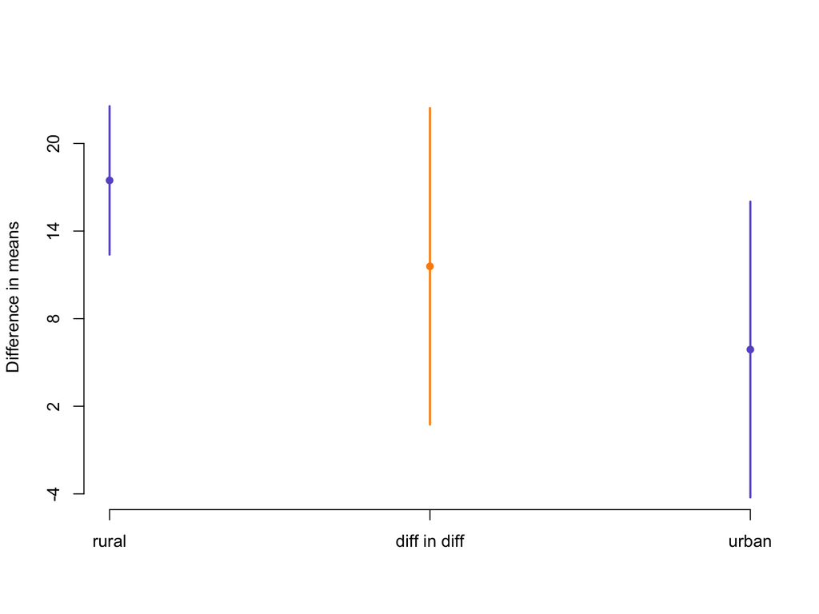

```r
upper <- diff_in_diff + 1.96*SE_diff
lower <- diff_in_diff - 1.96*SE_diff
min <- min(min, lower)

plot(1:2, c(d.r, d.u), ylim=c(min,max), pch=16, col="slateblue",
     ylab="Difference in means", axes=F, xlab="")
segments(1:2, c(test.rural$conf.int[1], test.urban$conf.int[1]),
         1:2, c(test.rural$conf.int[2], test.urban$conf.int[2]),
         lwd=2, col="slateblue")
axis(2, seq(min, max, round(abs(max/min), 0)))
points(1.5, diff_in_diff, pch=16, col="darkorange")
segments(1.5, upper,  1.5, lower, lwd=2, col="darkorange")
axis(1, c(1, 1.5, 2), labels=c("rural", "diff in diff", "urban"))
```

How should we interpret this difference?